# Analiza Uzależnienia Studentów od Mediów Społecznościowych

Marta Kaczmarkiewicz, Natalia Gaik, Michał Biesiadowski

30 styczeń 2026

# 1 1. Wprowadzenie

## 1.1 Teoretyczne podstawy uzależnienia od mediów społecznościowych

Uzależnienie od mediów społecznościowych stanowi współczesne wyzwanie w kontekście zdrowia psychicznego i społecznego młodych dorosłych. Zgodnie z koncepcjami psychologicznymi, uzależnienie cyfrowe można rozumieć jako kompulsywne zachowanie, charakteryzujące się utratą kontroli nad czasem spędzonym online, negatywnymi konsekwencjami dla codziennego funkcjonowania oraz trudnościami w ograniczeniu użytkowania. W literaturze przedmiotu podkreśla się, że nadmierne korzystanie z platform społecznościowych może prowadzić do izolacji społecznej, obniżonego samopoczucia oraz problemów z koncentracją. Badania wskazują na związek między czasem online a deficytami snu, zdrowiem psychicznym oraz wynikami edukacyjnymi, co postaramy się zbadać w niniejszym projekcie.

## 1.2 Cel i zakres analizy

Celem niniejszego projektu jest zbadanie relacji między sposobem korzystania z mediów społecznościowych a subiektywnym dobrostanem studentów. W dobie powszechnej cyfryzacji, zrozumienie cyfrowych nawyków młodych dorosłych staje się kluczowe dla identyfikacji potencjalnych ryzyk związanych z nadużywaniem technologii. W badaniu koncentrujemy się na weryfikacji, czy czas spędzany online oraz rodzaj wybieranej platformy współwystępują z niższą oceną zdrowia psychicznego, gorszą jakością snu oraz poczuciem uzależnienia.

## 1.3 Charakterystyka danych

Analiza została przeprowadzona na zbiorze danych obejmującym 705 obserwacji. Dane mają charakter deklaratywny i zostały zebrane metodą ankietową. Zmienne wykorzystane w badaniu obejmują:

**Zmienne demograficzne:** - Wiek - Płeć - Poziom studiów

**Zmienne behawioralne:** - Avg_Daily_Usage_Hours (Czas_h): Średnia liczba godzin spędzanych dziennie w mediach społecznościowych. - Most_Used_Platform (Platforma): Najczęściej wybierana aplikacja społecznościowa. - Conflicts_Over_Social_Media (Konflikty): Liczba sytuacji konfliktowych z otoczeniem, których źródłem było korzystanie z mediów społecznościowych.

**Pytania badawcze:** 1. Czy istnieje istotna statystycznie zależność między czasem spędzanym w mediach społecznościowych a subiektywną oceną zdrowia psychicznego? 2. Czy płeć różnicuje poziom uzależnienia od mediów społecznościowych oraz preferencje dotyczące wyboru platformy? 3. Czy studenci na niższych szczeblach edukacji (High School) wykazują wyższy poziom uzależnienia niż studenci studiów magisterskich (Academic_level)? 4. W jakim stopniu deficyt snu jest powiązany z intensywnością korzystania z social mediów? 5. Czy wyższy poziom uzależnienia od mediów społecznościowych wiąże się z częstszym deklarowaniem negatywnego wpływu tych mediów na wyniki w nauce? 6. Czy osoby deklarujące negatywny wpływ mediów społecznościowych na wyniki w nauce charakteryzują się wyższym poziomem uzależnienia? Które grupy wiekowe są najbardziej zagrożone tym zjawiskiem?

## 1.4 Przygotowanie środowiska

Do przetwarzania i wizualizacji danych wykorzystano środowisko R oraz następujące biblioteki:

```r
# Konfiguracja osobistej biblioteki pakietów
install_if_needed <- function(pkg) {
  if (!requireNamespace(pkg, quietly = TRUE)) {
    install.packages(pkg, dependencies = TRUE)
  }
  library(pkg, character.only = TRUE)
}
# Pakiety używane w dokumencie
pkgs <- c(
  "tidyverse",
  "corrplot",
  "knitr",
  "kableExtra",
  "ggthemes",
  "summarytools",
  "psych",
  "classInt",
  "ggpubr",
  "frequency",
  "ggstatsplot",
  "FSA",
  "nortest"
)

# Instalacja i załadowanie wszystkich pakietów
invisible(lapply(pkgs, install_if_needed))

# Ustawienie estetyki wykresów
theme_set(theme_minimal())
```

```r
# Wczytanie danych
dane <- read_csv("Students Social Media Addiction.csv")

# Podstawowy przegląd
glimpse(dane)
```

```
## Rows: 705
## Columns: 13
## $ Student_ID                   <dbl> 1, 2, 3, 4, 5, 6, 7, 8, 9, 10, 11, 12, 13…
## $ Age                          <dbl> 19, 22, 20, 18, 21, 19, 23, 20, 18, 21, 1…
## $ Gender                       <chr> "Female", "Male", "Female", "Male", "Male…
## $ Academic_Level               <chr> "Undergraduate", "Graduate", "Undergradua…
## $ Country                      <chr> "Bangladesh", "India", "USA", "UK", "Cana…
## $ Avg_Daily_Usage_Hours        <dbl> 5.2, 2.1, 6.0, 3.0, 4.5, 7.2, 1.5, 5.8, 4…
## $ Most_Used_Platform           <chr> "Instagram", "Twitter", "TikTok", "YouTub…
## $ Affects_Academic_Performance <chr> "Yes", "No", "Yes", "No", "Yes", "Yes", "…
## $ Sleep_Hours_Per_Night        <dbl> 6.5, 7.5, 5.0, 7.0, 6.0, 4.5, 8.0, 6.0, 6…
## $ Mental_Health_Score          <dbl> 6, 8, 5, 7, 6, 4, 9, 6, 7, 7, 5, 6, 8, 5,…
## $ Relationship_Status          <chr> "In Relationship", "Single", "Complicated…
## $ Conflicts_Over_Social_Media  <dbl> 3, 0, 4, 1, 2, 5, 0, 2, 1, 1, 3, 2, 1, 4,…
## $ Addicted_Score               <dbl> 8, 3, 9, 4, 7, 9, 2, 8, 5, 4, 7, 8, 4, 9,…
```

# 2 2. Przygotowanie danych

## 2.1 Sprawdzenie kompletności danych

```r
# Sprawdzenie brakujących wartości w każdej kolumnie
braki <- dane %>%
  summarise(across(everything(), ~sum(is.na(.))))

# Wyświetlenie tabeli braków
braki %>%
  pivot_longer(cols = everything(), names_to = "Zmienna", values_to = "Liczba_braków") %>%
  kbl(caption = "Liczba braków danych w poszczególnych kolumnach") %>%
  kable_styling(full_width = FALSE, font_size = 10, bootstrap_options = c("striped", "hover", "condensed")) %>%
  row_spec(0, bold = TRUE, font_size = 12) %>%
  scroll_box(
    width = "60%",
    height = "250px"
  )
```

Liczba braków danych w poszczególnych kolumnach

| Zmienna | Liczba_braków |
| --- | --- |
| Student_ID | 0 |
| Age | 0 |
| Gender | 0 |
| Academic_Level | 0 |
| Country | 0 |
| Avg_Daily_Usage_Hours | 0 |
| Most_Used_Platform | 0 |
| Affects_Academic_Performance | 0 |
| Sleep_Hours_Per_Night | 0 |
| Mental_Health_Score | 0 |
| Relationship_Status | 0 |
| Conflicts_Over_Social_Media | 0 |
| Addicted_Score | 0 |

```r
# Całkowita liczba braków w zbiorze
suma_brakow <- sum(is.na(dane))
procent_brakow <- (suma_brakow / (nrow(dane) * ncol(dane))) * 100
```

## 2.2 Transformacja i tłumaczenie

```r
dane_clean <- dane %>%
  rename(
    ID = Student_ID,
    Wiek = Age,
    Plec = Gender,
    Poziom_akademicki = Academic_Level,
    Kraj = Country,
    Sredni_Czas_Użytkowania = Avg_Daily_Usage_Hours,
    Najczęściej_używana_platforma = Most_Used_Platform,
    Wplyw_na_wyniki = Affects_Academic_Performance,
    Godziny_snu = Sleep_Hours_Per_Night,
    Ocena_zdrowia_psychicznego = Mental_Health_Score,
    Konflikty_w_social_mediach = Conflicts_Over_Social_Media,
    Wynik_uzaleznienia = Addicted_Score
  ) %>%
  mutate(
    # Konwersja na faktory
    f.Plec = as.factor(Plec),
    f.Platforma = as.factor(Najczęściej_używana_platforma), # Poprawione odwołanie do nowej nazwy
    f.Wplyw_na_wyniki = as.factor(Wplyw_na_wyniki),

    # Grupy użytkowników (Feature Engineering)
    Grupa_Czasu_Uzytkowania = case_when(
      Sredni_Czas_Użytkowania <= 2 ~ "Niski (0-2h)", # Poprawione odwołanie do nowej nazwy
      Sredni_Czas_Użytkowania <= 5 ~ "Średni (2-5h)",
      TRUE ~ "Wysoki (>5h)"
    ),
    f.Grupa_Czasu_Uzytkowania = factor(Grupa_Czasu_Uzytkowania,
                                       levels = c("Niski (0-2h)", "Średni (2-5h)", "Wysoki (>5h)")),

    # Deficyt snu
    Deficyt_snu = 7 - Godziny_snu
  )

# Podgląd przetworzonych danych
head(dane_clean) %>%
  kbl(caption = "Fragment przetworzonego zbioru danych") %>%
  kable_styling(
    full_width = FALSE,
    position = "center",
    font_size = 10,
    bootstrap_options = c("striped", "hover", "condensed")
  ) %>%
  row_spec(0, bold = TRUE, font_size = 12) %>%
  scroll_box(
    width = "80%",
    height = "300px"
  )
```

Fragment przetworzonego zbioru danych

| ID | Wiek | Plec | Poziom_akademicki | Kraj | Sredni_Czas_Użytkowania | Najczęściej_używana_platforma | Wplyw_na_wyniki | Godziny_snu | Ocena_zdrowia_psychicznego | Relationship_Status | Konflikty_w_social_mediach | Wynik_uzaleznienia | f.Plec | f.Platforma | f.Wplyw_na_wyniki | Grupa_Czasu_Uzytkowania | f.Grupa_Czasu_Uzytkowania | Deficyt_snu |
| --- | --- | --- | --- | --- | --- | --- | --- | --- | --- | --- | --- | --- | --- | --- | --- | --- | --- | --- |
| 1 | 19 | Female | Undergraduate | Bangladesh | 5.2 | Instagram | Yes | 6.5 | 6 | In Relationship | 3 | 8 | Female | Instagram | Yes | Wysoki (>5h) | Wysoki (>5h) | 0.5 |
| 2 | 22 | Male | Graduate | India | 2.1 | Twitter | No | 7.5 | 8 | Single | 0 | 3 | Male | Twitter | No | Średni (2-5h) | Średni (2-5h) | -0.5 |
| 3 | 20 | Female | Undergraduate | USA | 6.0 | TikTok | Yes | 5.0 | 5 | Complicated | 4 | 9 | Female | TikTok | Yes | Wysoki (>5h) | Wysoki (>5h) | 2.0 |
| 4 | 18 | Male | High School | UK | 3.0 | YouTube | No | 7.0 | 7 | Single | 1 | 4 | Male | YouTube | No | Średni (2-5h) | Średni (2-5h) | 0.0 |
| 5 | 21 | Male | Graduate | Canada | 4.5 | Facebook | Yes | 6.0 | 6 | In Relationship | 2 | 7 | Male | Facebook | Yes | Średni (2-5h) | Średni (2-5h) | 1.0 |
| 6 | 19 | Female | Undergraduate | Australia | 7.2 | Instagram | Yes | 4.5 | 4 | Complicated | 5 | 9 | Female | Instagram | Yes | Wysoki (>5h) | Wysoki (>5h) | 2.5 |

## 2.3 Walidacja spójności logicznej

```r
# Definicja kryteriów i zliczanie przypadków
wyniki_weryfikacji <- dane_clean %>%
  summarise(
    `Ocena zdrowia = 10 przy śnie < 4h` = sum(Ocena_zdrowia_psychicznego == 10 & Godziny_snu < 4, na.rm = TRUE),
    `Suma czasu (Media + Sen) > 22h` = sum(Sredni_Czas_Użytkowania + Godziny_snu > 22, na.rm = TRUE),
    `Wiek < 18 lat na poziomie Graduate` = sum(Wiek < 18 & Poziom_akademicki == "Graduate", na.rm = TRUE),
    `Maksymalne uzależnienie (10) bez wpływu na naukę` = sum(Wynik_uzaleznienia == 10 & Wplyw_na_wyniki == "No", na.rm = TRUE),
    `Maksymalne uzależnienie (10) bez konfliktów` = sum(Wynik_uzaleznienia == 10 & Konflikty_w_social_mediach == 0, na.rm = TRUE)
  ) %>%
  pivot_longer(cols = everything(), names_to = "Kryterium weryfikacji", values_to = "Liczba przypadków")

# Uzasadnienie
tabela_opisowa <- tibble(
  `Kryterium weryfikacji` = c(
    "Ocena zdrowia = 10 przy śnie < 4h",
    "Suma czasu (Media + Sen) > 22h",
    "Wiek < 18 lat na poziomie Graduate",
    "Maksymalne uzależnienie (10) bez wpływu na naukę",
    "Maksymalne uzależnienie (10) bez konfliktów"
  ),
  `Dlaczego to sprawdzamy?` = c(
    "Biologicznie trudne do utrzymania.",
    "Brak czasu na fizjologiczne potrzeby i naukę.",
    "Mało prawdopodobne osiągnięcie poziomu magisterskiego przed 18 r.ż.",
    "Skrajne uzależnienie zazwyczaj wpływa na wyniki.",
    "Silne uzależnienie zazwyczaj generuje spory z otoczeniem."
  )
)

# Połączenie i wyświetlenie tabeli
left_join(tabela_opisowa, wyniki_weryfikacji, by = "Kryterium weryfikacji") %>%
  kbl(caption = "Zestawienie potencjalnych niespójności w danych") %>%
  kable_styling(full_width = F, font_size = 10, bootstrap_options = c("striped", "hover")) %>%
  column_spec(3, bold = TRUE, color = ifelse(wyniki_weryfikacji$`Liczba przypadków` > 0, "red", "green")) %>%
  scroll_box(
    width = "80%",
    height = "300px"
  )
```

Zestawienie potencjalnych niespójności w danych

| Kryterium weryfikacji | Dlaczego to sprawdzamy? | Liczba przypadków |
| --- | --- | --- |
| Ocena zdrowia = 10 przy śnie < 4h | Biologicznie trudne do utrzymania. | 0 |
| Suma czasu (Media + Sen) > 22h | Brak czasu na fizjologiczne potrzeby i naukę. | 0 |
| Wiek < 18 lat na poziomie Graduate | Mało prawdopodobne osiągnięcie poziomu magisterskiego przed 18 r.ż. | 0 |
| Maksymalne uzależnienie (10) bez wpływu na naukę | Skrajne uzależnienie zazwyczaj wpływa na wyniki. | 0 |
| Maksymalne uzależnienie (10) bez konfliktów | Silne uzależnienie zazwyczaj generuje spory z otoczeniem. | 0 |

## 2.4 Podsumowanie przygotowania danych

W rozdziale 2 skupiono się na przygotowaniu danych do analizy. Weryfikacja kompletności danych wykazała brak braków danych we wszystkich kolumnach, co pozwoliło na dalsze przetwarzanie bez konieczności imputacji. Następnie przeprowadzono transformację danych, obejmującą: 1. Tłumaczenie nazw zmiennych na język polski dla lepszej czytelności 2. Konwersję zmiennych na odpowiednie typy (np. faktory dla zmiennych kategorycznych) 3. Inżynierię cech, taką jak utworzenie grup czasowych użytkowania mediów oraz obliczenie deficytu snu.

Dodatkowo, zweryfikowano spójność logiczną danych poprzez sprawdzenie potencjalnych niespójności, takich jak biologicznie niemożliwe kombinacje (np. doskonałe zdrowie przy minimalnym śnie), co pomogło nam potwierdzić jakość zbioru danych. Wszystkie przekształcenia miały na celu ułatwienie analizy, zapewnienie poprawności typów danych oraz przygotowanie zmiennych do dalszych etapów badania.

# 3 3. Eksploracja danych

W rozdziale przedstawiono strukturę próby i rozkłady podstawowych zmiennych. Materiał ma charakter eksploracyjny, służy identyfikacji wstępnych wzorców przed analizami wnioskowania.

## 3.1 Charakterystyka próby

### 3.1.1 Struktura demograficzna

```r
# Przygotowanie danych
dane$Gender <- as.factor(dane$Gender)
dane$Academic_Level <- factor(dane$Academic_Level,
                             levels = c("High School", "Undergraduate", "Graduate"),
                              ordered = TRUE)
dane$Most_Used_Platform <- as.factor(dane$Most_Used_Platform)
dane$Affects_Academic_Performance <- as.factor(dane$Affects_Academic_Performance)

# Tabela liczebności i procentów dla zmiennych demograficznych
demografia <- dane_clean %>%
  select(Plec, Poziom_akademicki, Kraj) %>%
  pivot_longer(cols = everything(), names_to = "Zmienna", values_to = "Kategoria") %>%
  count(Zmienna, Kategoria) %>%
  group_by(Zmienna) %>%
  mutate(Procent = round(n / sum(n) * 100, 1)) %>%
  ungroup() %>%
  arrange(Zmienna, desc(n))

demografia %>%
  kbl(caption = "Struktura demograficzna próby",
      col.names = c("Zmienna", "Kategoria", "Liczebność (n)", "Udział (%)")) %>%
  kable_styling(full_width = FALSE, position = "center", bootstrap_options = c("striped", "hover")) %>%
  row_spec(0, bold = TRUE, font_size = 12) %>%
  scroll_box(width = "80%", height = "400px")
```

Struktura demograficzna próby

| Zmienna | Kategoria | Liczebność (n) | Udział (%) |
| --- | --- | --- | --- |
| Kraj | India | 53 | 7.5 |
| Kraj | USA | 40 | 5.7 |
| Kraj | Canada | 34 | 4.8 |
| Kraj | Denmark | 27 | 3.8 |
| Kraj | France | 27 | 3.8 |
| Kraj | Ireland | 27 | 3.8 |
| Kraj | Mexico | 27 | 3.8 |
| Kraj | Spain | 27 | 3.8 |
| Kraj | Switzerland | 27 | 3.8 |
| Kraj | Turkey | 27 | 3.8 |
| Kraj | UK | 22 | 3.1 |
| Kraj | Italy | 21 | 3.0 |
| Kraj | Japan | 21 | 3.0 |
| Kraj | Russia | 21 | 3.0 |
| Kraj | Bangladesh | 20 | 2.8 |
| Kraj | Maldives | 19 | 2.7 |
| Kraj | Nepal | 19 | 2.7 |
| Kraj | Pakistan | 19 | 2.7 |
| Kraj | Sri Lanka | 19 | 2.7 |
| Kraj | China | 16 | 2.3 |
| Kraj | Poland | 16 | 2.3 |
| Kraj | Australia | 14 | 2.0 |
| Kraj | Germany | 14 | 2.0 |
| Kraj | South Korea | 13 | 1.8 |
| Kraj | Brazil | 8 | 1.1 |
| Kraj | Finland | 8 | 1.1 |
| Kraj | Malaysia | 8 | 1.1 |
| Kraj | Netherlands | 8 | 1.1 |
| Kraj | New Zealand | 8 | 1.1 |
| Kraj | Singapore | 8 | 1.1 |

[output cut: 85 more lines]

Najwięcej danych pochodzi z Indii (7,5% próby). Następna najliczniejsza grupa pochodzi z USA (ponad 5%).

### 3.1.2 Podstawowe statystyki zmiennych ciągłych

```r
# Wybór zmiennych numerycznych i obliczenie statystyk
dane_clean %>%
  select(Wiek, Sredni_Czas_Użytkowania, Godziny_snu, Ocena_zdrowia_psychicznego, Wynik_uzaleznienia) %>%
  summary()
```

```
##       Wiek       Sredni_Czas_Użytkowania  Godziny_snu
##  Min.   :18.00   Min.   :1.500           Min.   :3.800
##  1st Qu.:19.00   1st Qu.:4.100           1st Qu.:6.000
##  Median :21.00   Median :4.800           Median :6.900
##  Mean   :20.66   Mean   :4.919           Mean   :6.869
##  3rd Qu.:22.00   3rd Qu.:5.800           3rd Qu.:7.700
##  Max.   :24.00   Max.   :8.500           Max.   :9.600
##  Ocena_zdrowia_psychicznego Wynik_uzaleznienia
##  Min.   :4.000              Min.   :2.000
##  1st Qu.:5.000              1st Qu.:5.000
##  Median :6.000              Median :7.000
##  Mean   :6.227              Mean   :6.437
##  3rd Qu.:7.000              3rd Qu.:8.000
##  Max.   :9.000              Max.   :9.000
```

Próba obejmuje osoby w wieku od 18 do 24 lat, przy czym średni wiek wynosi około 20,7 roku, a mediana 21 lat. Średni czas użytkowania wynosi niespełna 5 jednostek, przy umiarkowanym zróżnicowaniu obserwacji. Badani śpią przeciętnie około 6,9 godziny na dobę, a połowa próby mieści się w przedziale od 6 do 7,7 godziny snu. Samoocena zdrowia psychicznego kształtuje się na umiarkowanie dobrym poziomie, ze średnią równą 6,2 i medianą 6 punktów. Wynik uzależnienia ma średnią wartość około 6,4, co wskazuje na przeciętny poziom nasilenia tego zjawiska w badanej grupie.

## 3.2 Analiza czasu użytkowania mediów społecznościowych

### 3.2.1 Statystyki czasu użytkowania

```r
# Szczegółowe miary położenia dla czasu
dane_clean %>%
  summarise(
    Srednia = mean(Sredni_Czas_Użytkowania),
    Mediana = median(Sredni_Czas_Użytkowania),
    Odchylenie_Std = sd(Sredni_Czas_Użytkowania),
    Min = min(Sredni_Czas_Użytkowania),
    Max = max(Sredni_Czas_Użytkowania),
    Q1 = quantile(Sredni_Czas_Użytkowania, 0.25),
    Q3 = quantile(Sredni_Czas_Użytkowania, 0.75)
  ) %>%
  kbl(caption = "Charakterystyki opisowe czasu użytkowania mediów społecznościowych", digits = 2) %>%
  kable_styling(full_width = F, bootstrap_options = c("striped", "hover")) %>%
  row_spec(0, bold = TRUE, font_size = 12)
```

Charakterystyki opisowe czasu użytkowania mediów społecznościowych

| Srednia | Mediana | Odchylenie_Std | Min | Max | Q1 | Q3 |
| --- | --- | --- | --- | --- | --- | --- |
| 4.92 | 4.8 | 1.26 | 1.5 | 8.5 | 4.1 | 5.8 |

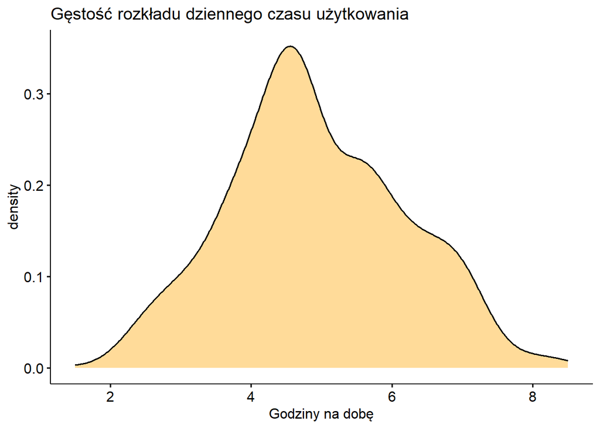

```r
ggdensity(dane, x = "Avg_Daily_Usage_Hours", fill = "orange", alpha = 0.4) +
   labs(title = "Gęstość rozkładu dziennego czasu użytkowania", x = "Godziny na dobę")
```

Średnia długość użytkowania wynosi 4,92, a odchylenie standardowe 1,26. Połowa studentów spędza czas w mediach społecznościowych od 4,1 do 5,8 godziny dziennie.

### 3.2.2 Rozkład czasu według kategorii

```r
# Analiza stworzonych grup (Niski/Średni/Wysoki)
dane_grupy <- dane_clean %>%
 count(f.Grupa_Czasu_Uzytkowania) %>%
   mutate(Udzial_procentowy = round(n / sum(n) * 100, 2))
dane_grupy %>%
  kbl(caption = "Struktura badanej próby według grup czasu użytkowania",
      col.names = c("Grupa czasu", "Liczebność (n)", "Udział (%)")) %>%
  kable_styling(full_width = F, bootstrap_options = c("striped", "hover")) %>%
  row_spec(0, bold = TRUE, font_size = 12)
```

Struktura badanej próby według grup czasu użytkowania

| Grupa czasu | Liczebność (n) | Udział (%) |
| --- | --- | --- |
| Niski (0-2h) | 2 | 0.28 |
| Średni (2-5h) | 409 | 58.01 |
| Wysoki (>5h) | 294 | 41.70 |

Większość studentów zalicza się do grupy ze średnim czasem użytkowania, czyli 2-5 godzin dziennie, jednak dużo liczniejsza jest grupa z wynikiem “wysoki” niż z wynikiem “niski”.

### 3.2.3 Najpopularniejsze platformy

```r
# Ranking platform
dane_clean %>%
  count(Najczęściej_używana_platforma) %>%
  arrange(desc(n)) %>%
  mutate(Procent = round(n / sum(n) * 100, 1))%>%
  kbl(caption = "Ranking najczęściej używanych platform mediów społecznościowych",
      col.names = c("Platforma", "Liczba użytkowników (n)", "Udział (%)")) %>%
  kable_styling(
    full_width = FALSE,
    bootstrap_options = c("striped", "hover")
  ) %>%
  row_spec(0, bold = TRUE, font_size = 12) %>%
  scroll_box(
    width = "70%",
    height = "350px"
  )
```

Ranking najczęściej używanych platform mediów społecznościowych

| Platforma | Liczba użytkowników (n) | Udział (%) |
| --- | --- | --- |
| Instagram | 249 | 35.3 |
| TikTok | 154 | 21.8 |
| Facebook | 123 | 17.4 |
| WhatsApp | 54 | 7.7 |
| Twitter | 30 | 4.3 |
| LinkedIn | 21 | 3.0 |
| WeChat | 15 | 2.1 |
| Snapchat | 13 | 1.8 |
| KakaoTalk | 12 | 1.7 |
| LINE | 12 | 1.7 |
| VKontakte | 12 | 1.7 |
| YouTube | 10 | 1.4 |

Najpopularniejszą platformą jest Instagram, z którego korzysta 35,3% studentów w próbie, następnie TikTok (21,8%) i Facebook (17,4%).

## 3.3 Analiza poziomu uzależnienia

### 3.3.1 Rozkład wyniku uzależnienia

```r
# Statystyki dla Wynik_uzaleznienia
dane_clean %>%
  summarise(
    Srednia_Uzaleznienie = mean(Wynik_uzaleznienia),
    Mediana = median(Wynik_uzaleznienia),
    SD = sd(Wynik_uzaleznienia)
  )%>%
  kbl(caption = "Statystyki opisowe poziomu uzależnienia studentów",
      col.names = c("Średnia", "Mediana", "Odchylenie standardowe"),
      digits = 2) %>%
  kable_styling(full_width = F, bootstrap_options = c("striped", "hover")) %>%
  row_spec(0, bold = TRUE, font_size = 12)
```

Statystyki opisowe poziomu uzależnienia studentów

| Średnia | Mediana | Odchylenie standardowe |
| --- | --- | --- |
| 6.44 | 7 | 1.59 |

Średni poziom uzależnienia wynosi 6,44, a odchylenie wynosi 1,59.

### 3.3.2 Poziomy uzależnienia według kategorii

```r
# Tworzymy proste kategorie uzależnienia do tabeli
dane_clean %>%
  mutate(Kat_Uzaleznienia = case_when(
    Wynik_uzaleznienia <= 3 ~ "Niskie",
    Wynik_uzaleznienia <= 7 ~ "Umiarkowane",
    TRUE ~ "Wysokie"
  )) %>%
  count(Kat_Uzaleznienia) %>%
  mutate(Procent = round(n / sum(n) * 100, 1)) %>%
  arrange(desc(n))%>%
  kbl(caption = "Liczba studentów według poziomu uzależnienia",
      col.names = c("Kategoria uzależnienia", "Liczebność (n)", "Udział (%)")) %>%
  kable_styling(full_width = F, bootstrap_options = c("striped", "hover")) %>%
  row_spec(0, bold = TRUE, font_size = 12)
```

Liczba studentów według poziomu uzależnienia

| Kategoria uzależnienia | Liczebność (n) | Udział (%) |
| --- | --- | --- |
| Umiarkowane | 489 | 69.4 |
| Wysokie | 199 | 28.2 |
| Niskie | 17 | 2.4 |

Prawie 70% studentów wykazuje umiarkowany poziom uzależnienia, a niski poziom wykazuje tylko 2,4%, pozostałe 28% wykazuje wysoki poziom uzależnienia.

## 3.4 Analiza według płci

```r
# Porównanie kobiet i mężczyzn w kluczowych aspektach
dane_clean %>%
  group_by(f.Plec) %>%
  summarise(
    N = n(),
    Sredni_Czas = mean(Sredni_Czas_Użytkowania),
    Srednie_Uzaleznienie = mean(Wynik_uzaleznienia),
    Srednie_Zdrowie = mean(Ocena_zdrowia_psychicznego)
  )%>%
  kbl(caption = "Porównanie wskaźników aktywności i dobrostanu według płci",
      col.names = c("Płeć", "Liczebność (n)", "Śr. czas użytkowania", "Śr. wynik uzależnienia", "Śr. zdrowie psychiczne"),
      digits = 2) %>%
  kable_styling(full_width = F, bootstrap_options = c("striped", "hover", "condensed")) %>%
  row_spec(0, bold = TRUE, font_size = 12)
```

Porównanie wskaźników aktywności i dobrostanu według płci

| Płeć | Liczebność (n) | Śr. czas użytkowania | Śr. wynik uzależnienia | Śr. zdrowie psychiczne |
| --- | --- | --- | --- | --- |
| Female | 353 | 5.01 | 6.52 | 6.18 |
| Male | 352 | 4.83 | 6.36 | 6.28 |

## 3.5 Analiza według poziomu akademickiego

```r
# Czy poziom edukacyjny ma znaczenie?
dane_clean %>%
  group_by(Poziom_akademicki) %>%
  summarise(
    Sredni_Czas = mean(Sredni_Czas_Użytkowania),
    Sredni_Sen = mean(Godziny_snu),
    Srednie_Uzaleznienie = mean(Wynik_uzaleznienia)
  ) %>%
  arrange(desc(Sredni_Czas))%>%
  kbl(caption = "Charakterystyki aktywności w mediach społecznościowych i dobrostanu według poziomu akademickiego",
      col.names = c("Poziom akademicki", "Śr. czas użytkowania", "Śr. czas snu", "Śr. wynik uzależnienia"),
      digits = 2) %>%
  kable_styling(full_width = F, bootstrap_options = c("striped", "hover")) %>%
  row_spec(0, bold = TRUE, font_size = 12)
```

Charakterystyki aktywności w mediach społecznościowych i dobrostanu według poziomu akademickiego

| Poziom akademicki | Śr. czas użytkowania | Śr. czas snu | Śr. wynik uzależnienia |
| --- | --- | --- | --- |
| High School | 5.54 | 5.46 | 8.04 |
| Undergraduate | 5.00 | 6.83 | 6.49 |
| Graduate | 4.78 | 7.03 | 6.24 |

Studenci “High School” spędzają najwięcej czasu w mediach społecznościowych i wykazują najwyższy poziom uzależnienia, podczas gdy studenci “Graduate” mają najniższe wartości w obu tych aspektach.

## 3.6 Zdrowie psychiczne i sen

### 3.6.1 Jakość zdrowia psychicznego

```r
# Podsumowanie oceny zdrowia psychicznego
dane_clean %>%
  summarise(
    Srednia = mean(Ocena_zdrowia_psychicznego),
    Mediana = median(Ocena_zdrowia_psychicznego),
    Najnizsza = min(Ocena_zdrowia_psychicznego),
    Najwyzsza = max(Ocena_zdrowia_psychicznego)
  )%>%
  kbl(caption = "Statystyki opisowe oceny zdrowia psychicznego studentów",
      col.names = c("Średnia ocena", "Mediana", "Ocena minimalna", "Ocena maksymalna"),
      digits = 2) %>%
  kable_styling(full_width = F, bootstrap_options = c("striped", "hover")) %>%
  row_spec(0, bold = TRUE, font_size = 12)
```

Statystyki opisowe oceny zdrowia psychicznego studentów

| Średnia ocena | Mediana | Ocena minimalna | Ocena maksymalna |
| --- | --- | --- | --- |
| 6.23 | 6 | 4 | 9 |

Średnia ocena zdrowia psychicznego to 6,23 na 10, z czego najniższa wynosi 4 a najwyższa 9.

### 3.6.2 Jakość snu

```r
# Analiza snu i deficytów
stats_snu <- dane_clean %>%
  summarise(
    Srednia_Godzin = mean(Godziny_snu),
    Liczba_z_Deficytem = sum(Godziny_snu < 7), # Deficyt poniżej 7h
    Procent_z_Deficytem = mean(Godziny_snu < 7) * 100
  )%>%
  kbl(caption = "Analiza jakości snu",
      col.names = c("Średnia liczba godzin", "Liczba osób z deficytem (<7h)", "Procent osób z deficytem (%)"),
      digits = 2) %>%
  kable_styling(full_width = F, bootstrap_options = c("striped", "hover")) %>%
  row_spec(0, bold = TRUE, font_size = 12)

stats_snu
```

Analiza jakości snu

| Średnia liczba godzin | Liczba osób z deficytem (<7h) | Procent osób z deficytem (%) |
| --- | --- | --- |
| 6.87 | 359 | 50.92 |

Średnia długość snu wynosi 6,87 godzin, jednak aż 50% wykazuje deficyt snu , czyli poniżej 7 godzin.

## 3.7 Wpływ na wyniki akademickie

```r
# Jak studenci oceniają wpływ social mediów na swoje oceny?
dane_clean %>%
  group_by(f.Wplyw_na_wyniki) %>%
  summarise(
    Liczba = n(),
    Sredni_Czas_Uzytkowania = mean(Sredni_Czas_Użytkowania),
    Srednie_Uzaleznienie = mean(Wynik_uzaleznienia)
  ) %>%
  kbl(caption = "Aktywność w mediach społecznościowych a deklarowany wpływ na wyniki w nauce",
      col.names = c("Czy wpływa na wyniki?", "Liczebność (n)", "Śr. czas użytkowania", "Śr. wynik uzależnienia"),
      digits = 2) %>%
  kable_styling(full_width = F, bootstrap_options = c("striped", "hover")) %>%
  row_spec(0, bold = TRUE, font_size = 12)
```

Aktywność w mediach społecznościowych a deklarowany wpływ na wyniki w nauce

| Czy wpływa na wyniki? | Liczebność (n) | Śr. czas użytkowania | Śr. wynik uzależnienia |
| --- | --- | --- | --- |
| No | 252 | 3.80 | 4.60 |
| Yes | 453 | 5.54 | 7.46 |

Studenci, którzy twierdzą, że media społecznościowe mają wypływ na ich wyniki w nauce, spędzają średnio o 2 godzin więcej na platformach jak i wykazują większe uzależnienie, niż ci którzy nie wykazali wpływu na naukę

## 3.8 Konflikty związane z mediami społecznościowymi

```r
dane_clean %>%
  group_by(Konflikty_w_social_mediach) %>%
  summarise(
    Sredni_Wynik_Uzaleznienia = mean(Wynik_uzaleznienia),
    Licznosc = n()
  ) %>%
  kbl(caption = "Związek między konfliktami a średnim poziomem uzależnienia",
      col.names = c("Liczba konfliktów", "Śr. wynik uzależnienia", "Liczebność (n)"),
      digits = 2) %>%
  kable_styling(full_width = F, bootstrap_options = c("striped", "hover", "condensed")) %>%
  row_spec(0, bold = TRUE, font_size = 12)
```

Związek między konfliktami a średnim poziomem uzależnienia

| Liczba konfliktów | Śr. wynik uzależnienia | Liczebność (n) |
| --- | --- | --- |
| 0 | 2.75 | 4 |
| 1 | 3.85 | 47 |
| 2 | 4.85 | 204 |
| 3 | 6.86 | 261 |
| 4 | 8.22 | 174 |
| 5 | 9.00 | 15 |

```r
kor_konflikty <- cor(dane_clean$Konflikty_w_social_mediach, dane_clean$Wynik_uzaleznienia)

tibble(
  Metryka = "Korelacja Pearsona (konflikty - uzależnienie)",
  Wartość = round(kor_konflikty, 3)
) %>%
  kbl(caption = "Współczynnik korelacji", digits = 3) %>%
  kable_styling(full_width = F, bootstrap_options = c("striped", "hover", "condensed")) %>%
  row_spec(0, bold = TRUE, font_size = 12)
```

Współczynnik korelacji

| Metryka | Wartość |
| --- | --- |
| Korelacja Pearsona (konflikty - uzależnienie) | 0.934 |

Zachodzi korelacja między wynikiem uzależnienia a występowaniem konfliktów.

## 3.9 Korelacje między zmiennymi

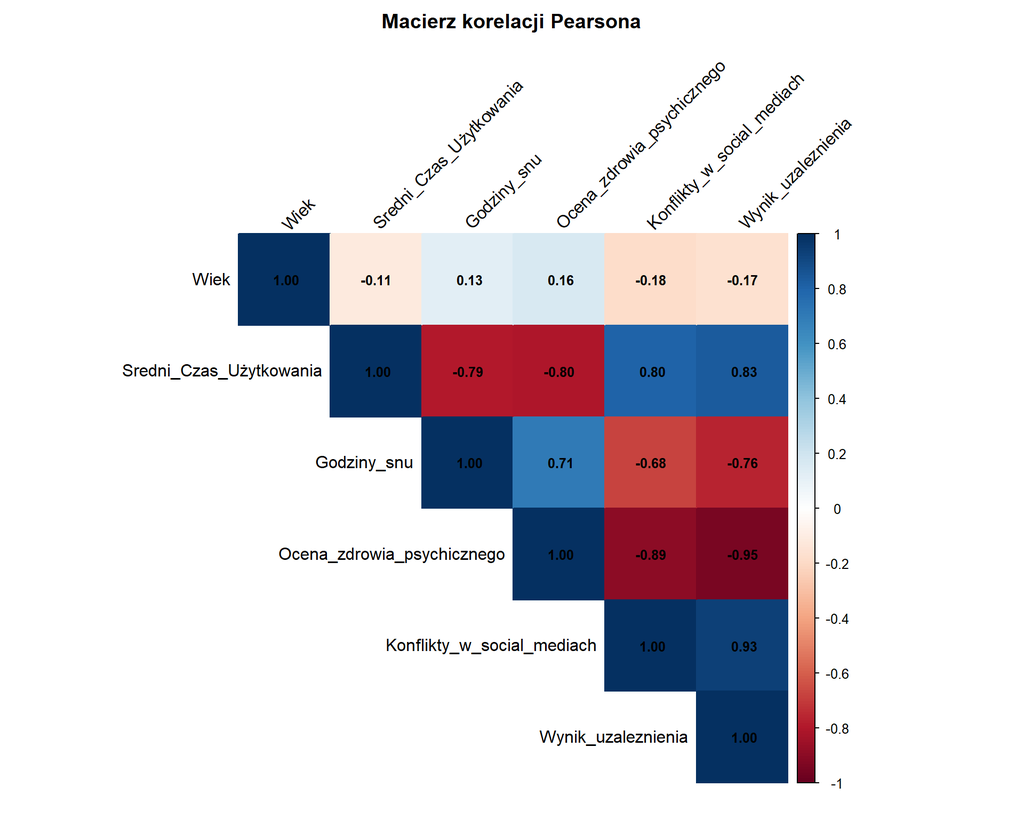

```r
zmienne_numeryczne <- dane_clean %>%
  select(Wiek, Sredni_Czas_Użytkowania, Godziny_snu, Ocena_zdrowia_psychicznego,
         Konflikty_w_social_mediach, Wynik_uzaleznienia)

M <- cor(zmienne_numeryczne)

corrplot(M,
         method = "color",
         type = "upper",
         addCoef.col = "black",
         tl.col = "black",
         tl.srt = 45,
         number.cex = 0.8,
         title = "Macierz korelacji Pearsona",
         mar = c(0, 0, 2, 0))
```

```r
M %>%
  kbl(caption = "Macierz korelacji Pearsona dla zmiennych ilościowych", digits = 3) %>%
  kable_styling(full_width = F, bootstrap_options = c("striped", "hover", "condensed")) %>%
  row_spec(0, bold = TRUE, font_size = 12)
```

Macierz korelacji Pearsona dla zmiennych ilościowych

|  | Wiek | Sredni_Czas_Użytkowania | Godziny_snu | Ocena_zdrowia_psychicznego | Konflikty_w_social_mediach | Wynik_uzaleznienia |
| --- | --- | --- | --- | --- | --- | --- |
| Wiek | 1.000 | -0.114 | 0.125 | 0.160 | -0.184 | -0.166 |
| Sredni_Czas_Użytkowania | -0.114 | 1.000 | -0.791 | -0.801 | 0.805 | 0.832 |
| Godziny_snu | 0.125 | -0.791 | 1.000 | 0.707 | -0.677 | -0.765 |
| Ocena_zdrowia_psychicznego | 0.160 | -0.801 | 0.707 | 1.000 | -0.894 | -0.945 |
| Konflikty_w_social_mediach | -0.184 | 0.805 | -0.677 | -0.894 | 1.000 | 0.934 |
| Wynik_uzaleznienia | -0.166 | 0.832 | -0.765 | -0.945 | 0.934 | 1.000 |

```r
tabela_wiek_kor <- as.data.frame(M[, 1])
tabela_wiek_kor$Zmienna <- rownames(tabela_wiek_kor)
tabela_wiek_kor <- tabela_wiek_kor %>%
  select(Zmienna, everything()) %>%
  rename(Korelacja_z_wiekiem = `M[, 1]`)

tabela_wiek_kor %>%
  kbl(caption = "Korelacja wieku z pozostałymi cechami ilościowymi", digits = 3) %>%
  kable_styling(full_width = F, bootstrap_options = c("striped", "hover", "condensed")) %>%
  row_spec(0, bold = TRUE, font_size = 12)
```

Korelacja wieku z pozostałymi cechami ilościowymi

|  | Zmienna | Korelacja_z_wiekiem |
| --- | --- | --- |
| Wiek | Wiek | 1.000 |
| Sredni_Czas_Użytkowania | Sredni_Czas_Użytkowania | -0.114 |
| Godziny_snu | Godziny_snu | 0.125 |
| Ocena_zdrowia_psychicznego | Ocena_zdrowia_psychicznego | 0.160 |
| Konflikty_w_social_mediach | Konflikty_w_social_mediach | -0.184 |
| Wynik_uzaleznienia | Wynik_uzaleznienia | -0.166 |

# 4 4. Wizualizacja Danych

“Obraz wart jest więcej niż tysiące słów”… W tej sekcji przedstawiono profesjonalne grafiki programowane przy użyciu pakietu ggplot2, wykorzystującego zasady warstwowego tworzenia wykresów. Wizualizacje służą do graficznej analizy rozkładów zmiennych oraz zależności między nimi, umożliwiając lepsze zrozumienie danych.

## 4.1 Rozkład czasu spędzanego w mediach społecznościowych

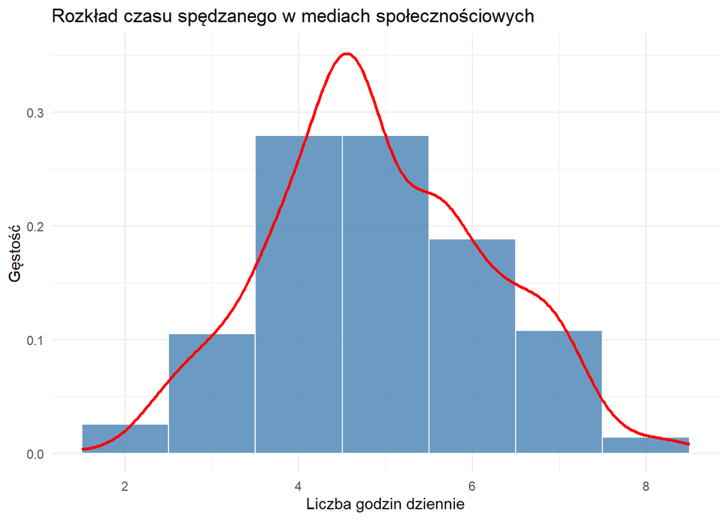

```r
ggplot(dane_clean, aes(x = Sredni_Czas_Użytkowania)) +
  geom_histogram(aes(y = ..density..),
                 binwidth = 1,
                 fill = "steelblue",
                 color = "white",
                 alpha = 0.8) +
  geom_density(color = "red", size = 1) +
  labs(title = "Rozkład czasu spędzanego w mediach społecznościowych",
       x = "Liczba godzin dziennie",
       y = "Gęstość") +
  theme_minimal()
```

Histogram przedstawia rozkład średniego czasu spędzanego dziennie w mediach społecznościowych. Rozkład jest asymetryczny prawostronnie, z maksimum około 5 godzin. Większość obserwacji koncentruje się w przedziale 4–6 godzin, ale widoczny jest „ogon” dla wartości powyżej 7–8 godzin, wskazujący na intensywnych użytkowników.

## 4.2 Poziom uzależnienia w zależności od platformy

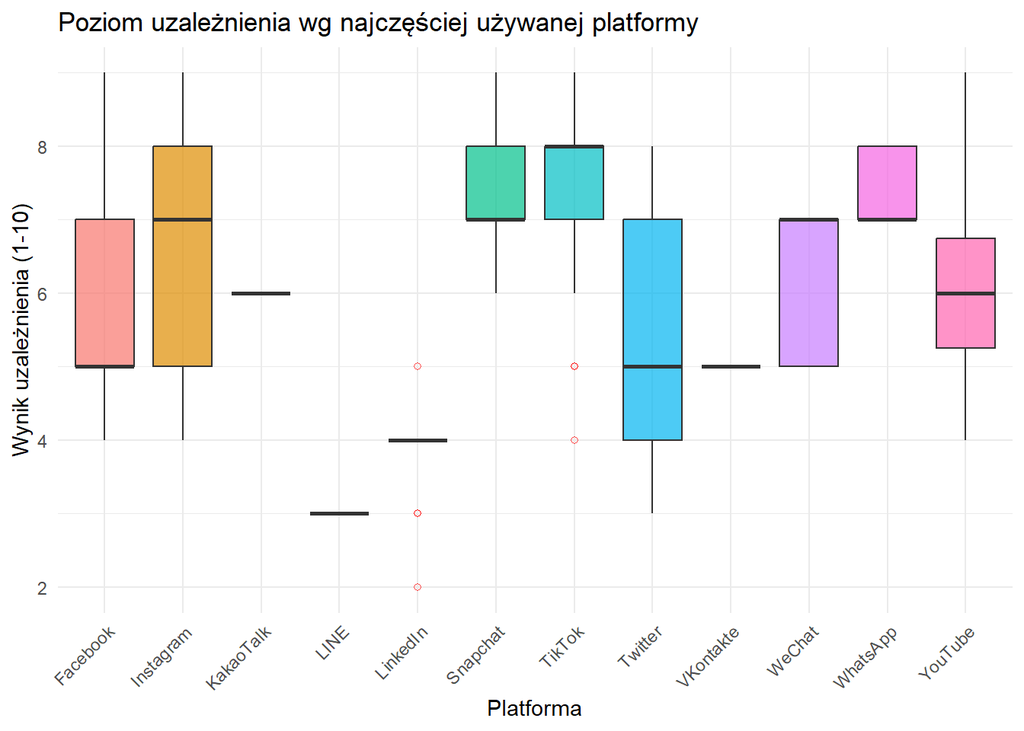

```r
ggplot(dane_clean, aes(x = f.Platforma, y = Wynik_uzaleznienia, fill = f.Platforma)) +
  geom_boxplot(alpha = 0.7, outlier.colour = "red", outlier.shape = 1) +
  labs(title = "Poziom uzależnienia wg najczęściej używanej platformy",
       x = "Platforma",
       y = "Wynik uzależnienia (1-10)") +
  theme_minimal() +
  theme(axis.text.x = element_text(angle = 45, hjust = 1),
        legend.position = "none")
```

Wykres pudełkowy pokazuje poziom uzależnienia w zależności od najczęściej używanej platformy. Najwyższe mediany uzależnienia obserwuje się dla WhatsApp, Instagram, Snapchat i TikTok. Dla mniej popularnych platform, takich jak LINE czy VKontakte, dane są mniej liczne.

## 4.3 Czas użytkowania a zdrowie psychiczne

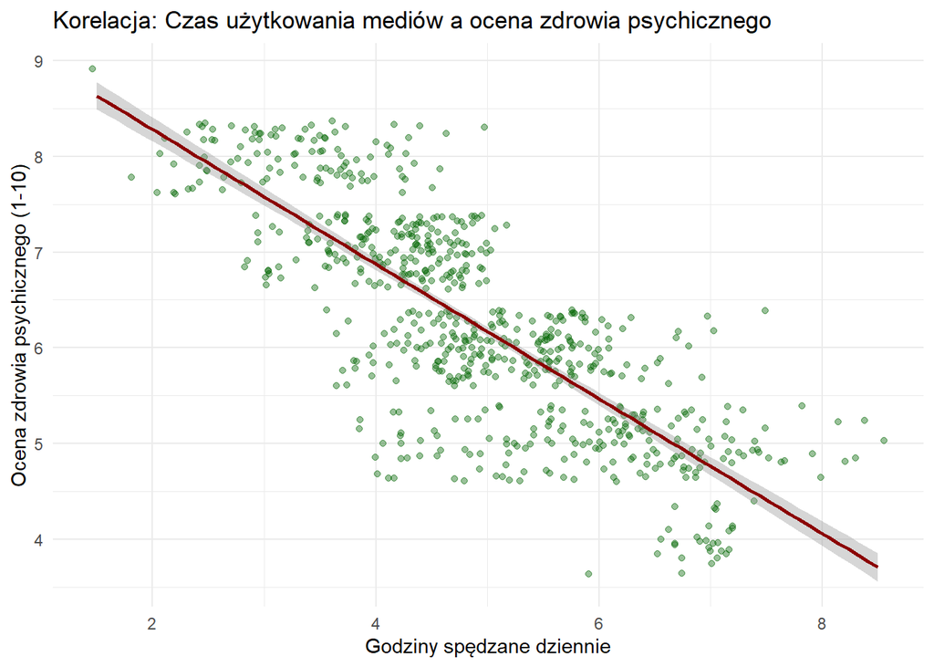

```r
ggplot(dane_clean, aes(x = Sredni_Czas_Użytkowania, y = Ocena_zdrowia_psychicznego)) +
  geom_jitter(color = "darkgreen", alpha = 0.4, width = 0.2) +
  geom_smooth(method = "lm", color = "darkred", se = TRUE) +
  labs(title = "Korelacja: Czas użytkowania mediów a ocena zdrowia psychicznego",
       x = "Godziny spędzane dziennie",
       y = "Ocena zdrowia psychicznego (1-10)") +
  theme_minimal()
```

Wykres punktowy z linią trendu pokazuje ujemną korelację między czasem użytkowania mediów społecznościowych a oceną zdrowia psychicznego. Wraz ze wzrostem godzin online, ocena zdrowia spada.

# 5 5. Wnioskowanie statystyczne

## 5.1 Hipoteza 1: Czas użytkowania a zdrowie psychiczne

**Pytanie badawcze:** Czy istnieje związek pomiędzy ilością czasu spędzanego w mediach społecznościowych a subiektywną oceną zdrowia psychicznego?

**Hipotezy:**

H_0: Nie ma istotnej korelacji między czasem spędzanym w mediach a oceną zdrowia psychicznego.

H_1: Istnieje istotna statystycznie korelacja między tymi zmiennymi.

Do weryfikacji wykorzystano współczynnik korelacji rang Spearmana.

```r
test_h1 <- cor.test(dane_clean$Sredni_Czas_Użytkowania,
                    dane_clean$Ocena_zdrowia_psychicznego,
                    method = "spearman")

tibble(
  Statystyka = c("Rho Spearmana", "Wartość p", "N"),
  Wartość = c(round(test_h1$estimate, 3),
              format.pval(test_h1$p.value, digits = 3),
              nrow(dane_clean))
) %>%
  kbl(caption = "Wyniki testu korelacji rang Spearmana") %>%
  kable_styling(full_width = F, bootstrap_options = c("striped", "hover", "condensed")) %>%
  row_spec(0, bold = TRUE, font_size = 12)
```

Wyniki testu korelacji rang Spearmana

| Statystyka | Wartość |
| --- | --- |
| Rho Spearmana | -0.802 |
| Wartość p | <2e-16 |
| N | 705 |

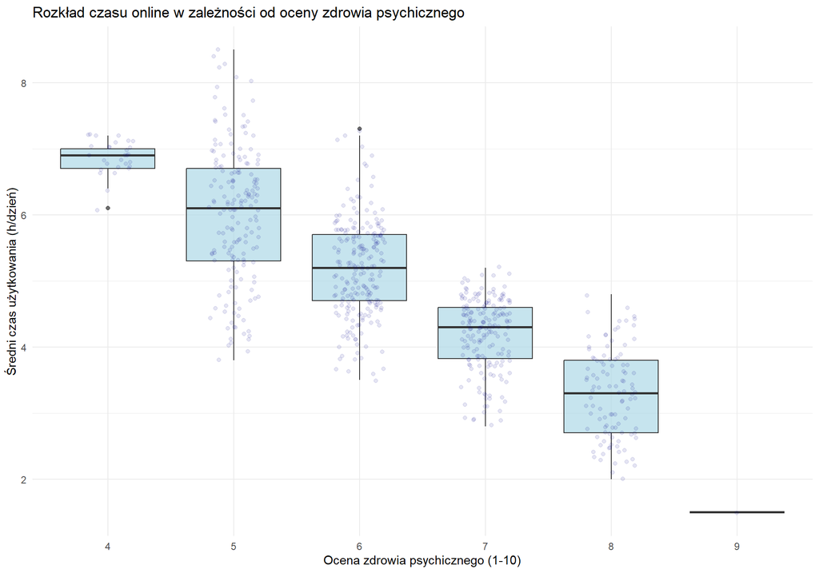

```r
ggplot(dane_clean, aes(x = as.factor(Ocena_zdrowia_psychicznego), y = Sredni_Czas_Użytkowania)) +
  geom_boxplot(fill = "lightblue", alpha = 0.7) +
  geom_jitter(alpha = 0.1, color = "darkblue", width = 0.2) +
  labs(
    title = "Rozkład czasu online w zależności od oceny zdrowia psychicznego",
    x = "Ocena zdrowia psychicznego (1-10)",
    y = "Średni czas użytkowania (h/dzień)"
  ) +
  theme_minimal()
```

## 5.2 Hipoteza 2: Płeć a poziom uzależnienia

**Pytanie badawcze:** Czy płeć różnicuje poziom uzależnienia od mediów społecznościowych?

**Hipotezy:**

H_0: Nie ma istotnych różnic w poziomie uzależnienia między kobietami a mężczyznami.

H_1: Występują istotne różnice w poziomie uzależnienia między kobietami a mężczyznami.

Zastosowano test U Manna-Whitneya (Wilcoxona dla dwóch prób niezależnych).

```r
test_h2 <- wilcox.test(Wynik_uzaleznienia ~ f.Plec, data = dane_clean)

mediany <- dane_clean %>%
  group_by(f.Plec) %>%
  summarise(Mediana = median(Wynik_uzaleznienia),
            N = n())

tibble(
  Grupa = mediany$f.Plec,
  Mediana = mediany$Mediana,
  N = mediany$N
) %>%
  kbl(caption = "Mediany poziomu uzależnienia według płci") %>%
  kable_styling(full_width = F, bootstrap_options = c("striped", "hover", "condensed")) %>%
  row_spec(0, bold = TRUE, font_size = 12)
```

Mediany poziomu uzależnienia według płci

| Grupa | Mediana | N |
| --- | --- | --- |
| Female | 7 | 353 |
| Male | 7 | 352 |

```r
tibble(
  Statystyka = c("Statystyka W", "Wartość p"),
  Wartość = c(test_h2$statistic, format.pval(test_h2$p.value, digits = 3))
) %>%
  kbl(caption = "Wyniki testu U Manna-Whitneya") %>%
  kable_styling(full_width = F, bootstrap_options = c("striped", "hover", "condensed")) %>%
  row_spec(0, bold = TRUE, font_size = 12)
```

Wyniki testu U Manna-Whitneya

| Statystyka | Wartość |
| --- | --- |
| Statystyka W | 66322.5 |
| Wartość p | 0.113 |

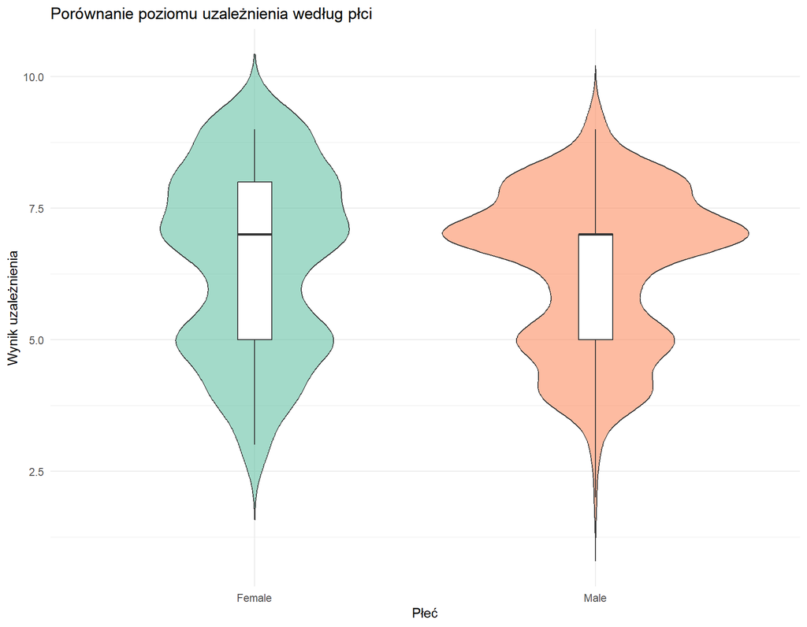

```r
ggplot(dane_clean, aes(x = f.Plec, y = Wynik_uzaleznienia, fill = f.Plec)) +
  geom_violin(trim = FALSE, alpha = 0.6) +
  geom_boxplot(width = 0.1, fill = "white") +
  labs(
    title = "Porównanie poziomu uzależnienia według płci",
    x = "Płeć",
    y = "Wynik uzależnienia"
  ) +
  scale_fill_brewer(palette = "Set2") +
  theme_minimal() +
  theme(legend.position = "none")
```

**Wnioski** Wartość p jest wyższa niż próg 0,05, oznacza to, że mamy brak podstaw do odrzucenia hipotezy zerowej. Różnica w poziomie uzależnienia między kobietami a mężczyznami nie jest istotna statystycznie. Wynik ten pokazuje, że płeć nie jest czynnikiem różnicującym skłonność do uzależnienia od mediów społecznościowych. Wykres skrzypcowy ilustruje zbliżony kształt rozkładów dla obu płci, z największą gęstością obserwacji koncentrującą się symetrycznie wokół tych samych, wysokich wartości.

## 5.3 Hipoteza 3: Płeć a wybór platformy

**Pytanie badawcze:** Czy istnieje zależność między płcią a preferowaną platformą społecznościową?

**Hipotezy:**

H_0: Płeć i wybór platformy są niezależne.

H_1: Istnieje zależność między płcią a wyborem głównej platformy.

Zastosowano test niezależności Chi-kwadrat ($\chi^2$).

```r
tabela_kontyngencji <- table(dane_clean$f.Plec, dane_clean$f.Platforma)
test_h3 <- chisq.test(tabela_kontyngencji)

tibble(
  Statystyka = c("Chi-kwadrat", "df", "Wartość p"),
  Wartość = c(round(test_h3$statistic, 2),
              test_h3$parameter,
              format.pval(test_h3$p.value, digits = 3))
) %>%
  kbl(caption = "Wyniki testu niezależności Chi-kwadrat") %>%
  kable_styling(full_width = F, bootstrap_options = c("striped", "hover", "condensed")) %>%
  row_spec(0, bold = TRUE, font_size = 12)
```

Wyniki testu niezależności Chi-kwadrat

| Statystyka | Wartość |
| --- | --- |
| Chi-kwadrat | 154.33 |
| df | 11 |
| Wartość p | <2e-16 |

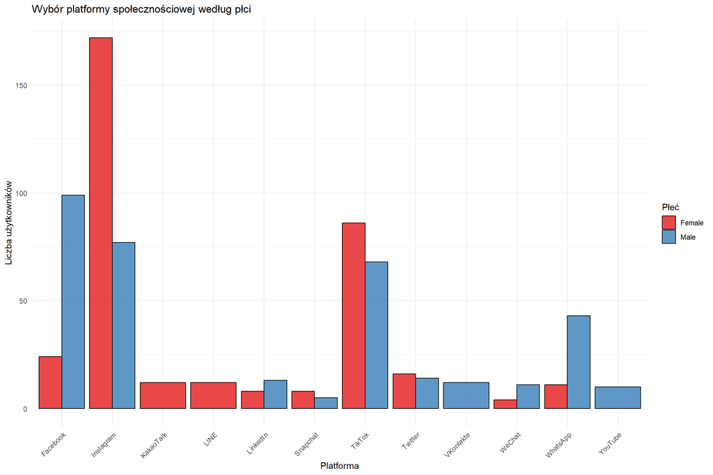

```r
dane_clean %>%
  droplevels() %>%
  ggplot(aes(x = f.Platforma, fill = f.Plec)) +
  geom_bar(position = "dodge", color = "black", alpha = 0.8) +
  labs(
    title = "Wybór platformy społecznościowej według płci",
    x = "Platforma",
    y = "Liczba użytkowników",
    fill = "Płeć"
  ) +
  scale_fill_brewer(palette = "Set1") +
  theme_minimal() +
  theme(axis.text.x = element_text(angle = 45, hjust = 1))
```

**Wnioski** Wartość p jest niższa od progu 0,05, co pozwala na odrzucenie hipotezy zerowej na rzecz hipotezy alternatywnej – istnieje zależność między płcią a wyborem platformy. Wykres słupkowy pokazuje wyraźne różnice w preferencjach platform między kobietami a mężczyznami. Kobiety dominują na Instagramie i TikTok (chociaż tutaj różnica nie jest duża), podczas gdy mężczyźni przeważają zdecydowanie na platformach takich jak Facebook, WhatsApp i YouTube.

## 5.4 Hipoteza 4: Poziom edukacji a uzależnienie

**Pytanie badawcze:** Czy występują różnice w poziomie uzależnienia pomiędzy studentami na różnych etapach edukacji?

**Hipotezy:**

H_0: Rozkłady poziomu uzależnienia są takie same we wszystkich grupach edukacyjnych.

H_1: Przynajmniej jedna grupa różni się poziomem uzależnienia od pozostałych.

Zastosowano test Kruskala-Wallisa (nieparametryczny odpowiednik ANOVA).

```r
test_h4 <- kruskal.test(Wynik_uzaleznienia ~ Poziom_akademicki, data = dane_clean)

mediany_edukacja <- dane_clean %>%
  group_by(Poziom_akademicki) %>%
  summarise(Mediana = median(Wynik_uzaleznienia),
            N = n())

mediany_edukacja %>%
  kbl(caption = "Mediany poziomu uzależnienia według poziomu akademickiego",
      col.names = c("Poziom akademicki", "Mediana", "N")) %>%
  kable_styling(full_width = F, bootstrap_options = c("striped", "hover", "condensed")) %>%
  row_spec(0, bold = TRUE, font_size = 12)
```

Mediany poziomu uzależnienia według poziomu akademickiego

| Poziom akademicki | Mediana | N |
| --- | --- | --- |
| Graduate | 7 | 325 |
| High School | 8 | 27 |
| Undergraduate | 7 | 353 |

```r
tibble(
  Statystyka = c("Chi-kwadrat", "df", "Wartość p"),
  Wartość = c(round(test_h4$statistic, 2),
              test_h4$parameter,
              format.pval(test_h4$p.value, digits = 3))
) %>%
  kbl(caption = "Wyniki testu Kruskala-Wallisa") %>%
  kable_styling(full_width = F, bootstrap_options = c("striped", "hover", "condensed")) %>%
  row_spec(0, bold = TRUE, font_size = 12)
```

Wyniki testu Kruskala-Wallisa

| Statystyka | Wartość |
| --- | --- |
| Chi-kwadrat | 39.1 |
| df | 2 |
| Wartość p | 3.23e-09 |

```r
if(test_h4$p.value < 0.05) {
  posthoc_h4 <- dunnTest(Wynik_uzaleznienia ~ Poziom_akademicki,
                         data = dane_clean, method = "bonferroni")
  posthoc_h4$res %>%
    kbl(caption = "Testy post-hoc (Dunn) z korektą Bonferroniego", digits = 3) %>%
    kable_styling(full_width = F, bootstrap_options = c("striped", "hover", "condensed")) %>%
    row_spec(0, bold = TRUE, font_size = 12)
}
```

Testy post-hoc (Dunn) z korektą Bonferroniego

| Comparison | Z | P.unadj | P.adj |
| --- | --- | --- | --- |
| Graduate - High School | -6.183 | 0.000 | 0.000 |
| Graduate - Undergraduate | -2.155 | 0.031 | 0.094 |
| High School - Undergraduate | 5.372 | 0.000 | 0.000 |

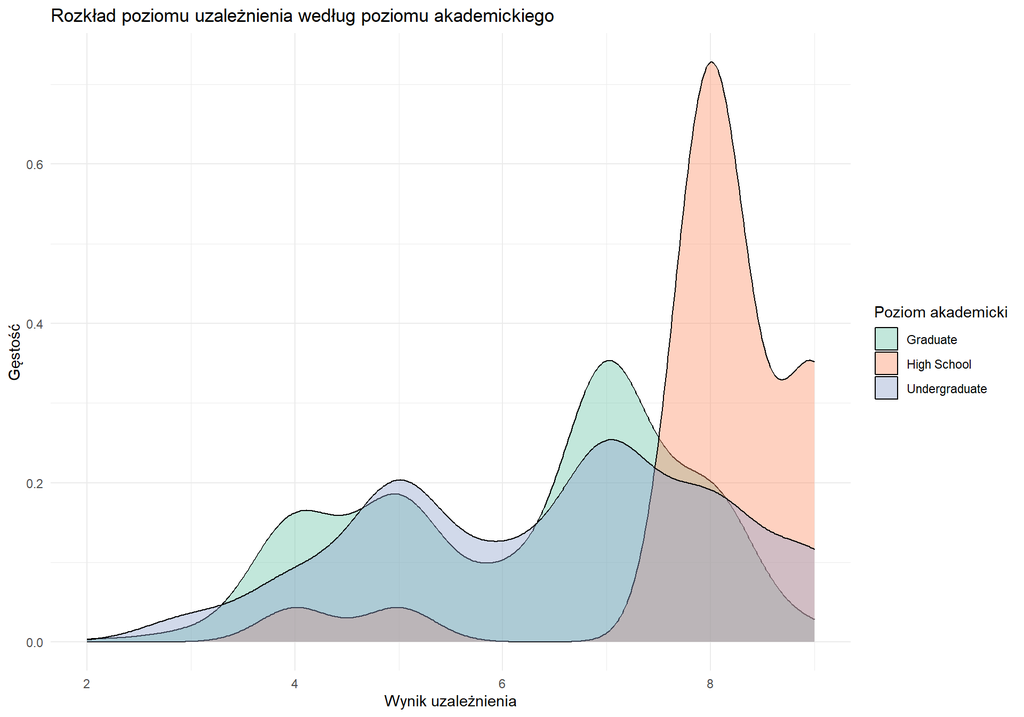

```r
ggplot(dane_clean, aes(x = Wynik_uzaleznienia, fill = Poziom_akademicki)) +
  geom_density(alpha = 0.4) +
  labs(
    title = "Rozkład poziomu uzależnienia według poziomu akademickiego",
    x = "Wynik uzależnienia",
    y = "Gęstość",
    fill = "Poziom akademicki"
  ) +
  scale_fill_brewer(palette = "Set2") +
  theme_minimal()
```

**Wnioski** Test Kruskala-Wallisa (p < 0.05) wykazał istotne różnice w poziomie uzależnienia pomiędzy studentami na różnych etapach edukacji. Testy post-hoc potwierdziły, że studenci na etapie High School wykazują statystycznie wyższą medianę uzależnienia niż studenci na poziomie Graduate. Wykres gęstości uwidacznia przesunięcie rozkładu dla uczniów szkół średnich w prawą stronę, co sygnalizuje większą koncentrację skrajnych wyników uzależnienia w tej grupie w porównaniu do osób, które ukończyły studia.

## 5.5 Hipoteza 5: Deficyt snu a czas online

**Pytanie badawcze:** Czy istnieje związek między czasem spędzanym w mediach społecznościowych a liczbą godzin snu?

**Hipotezy:**

H_0: Nie ma istotnej korelacji między czasem online a liczbą godzin snu.

H_1: Istnieje istotna korelacja między czasem spędzanym online a czasem snu.

Zastosowano współczynnik korelacji rang Spearmana.

```r
test_h5 <- cor.test(dane_clean$Sredni_Czas_Użytkowania,
                    dane_clean$Godziny_snu,
                    method = "spearman")

tibble(
  Statystyka = c("Rho Spearmana", "Wartość p", "N"),
  Wartość = c(round(test_h5$estimate, 3),
              format.pval(test_h5$p.value, digits = 3),
              nrow(dane_clean))
) %>%
  kbl(caption = "Wyniki testu korelacji rang Spearmana") %>%
  kable_styling(full_width = F, bootstrap_options = c("striped", "hover", "condensed")) %>%
  row_spec(0, bold = TRUE, font_size = 12)
```

Wyniki testu korelacji rang Spearmana

| Statystyka | Wartość |
| --- | --- |
| Rho Spearmana | -0.814 |
| Wartość p | <2e-16 |
| N | 705 |

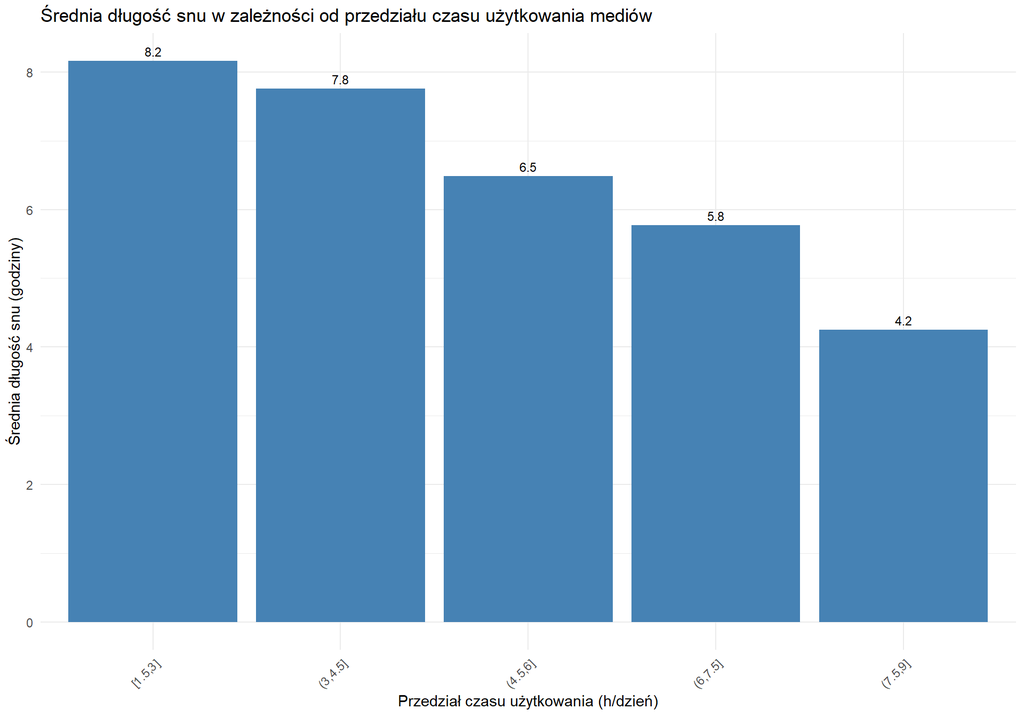

```r
dane_clean %>%
  mutate(przedzial_czasu = cut_width(Sredni_Czas_Użytkowania, width = 1.5, boundary = 0)) %>%
  group_by(przedzial_czasu) %>%
  summarise(sredni_sen = mean(Godziny_snu, na.rm = TRUE)) %>%
  ggplot(aes(x = przedzial_czasu, y = sredni_sen)) +
  geom_col(fill = "steelblue") +
  geom_text(aes(label = round(sredni_sen, 1)), vjust = -0.5, size = 3) +
  labs(
    title = "Średnia długość snu w zależności od przedziału czasu użytkowania mediów",
    x = "Przedział czasu użytkowania (h/dzień)",
    y = "Średnia długość snu (godziny)"
  ) +
  theme_minimal() +
  theme(axis.text.x = element_text(angle = 45, hjust = 1))
```

**Wnioski** Wartość p jest znacznie poniżej progu 0,05, co pozwala na odrzucenie hipotezy zerowej. Związek między czasem spędzonym w mediach społecznościowych a długością snu jest statystycznie istotny (Rho = -0,814). Wykres słupkowy średnich obrazuje schodkowy efekt tej relacji, gdzie przeciętna długość snu systematycznie maleje w kolejnych, coraz wyższych przedziałach czasowych użytkowania mediów.

## 5.6 Hipoteza 6: Uzależnienie a wpływ na wyniki w nauce według wieku

**Pytanie badawcze:** Czy osoby deklarujące negatywny wpływ mediów społecznościowych na wyniki w nauce mają wyższy poziom uzależnienia? Które grupy wiekowe są najbardziej zagrożone?

**Hipotezy:**

H_0: Poziom uzależnienia nie różni się między osobami deklarującymi i niedeklarującymi wpływu mediów na wyniki w nauce.

H_1: Osoby deklarujące wpływ mediów na wyniki w nauce mają istotnie wyższy poziom uzależnienia.

Zastosowano test U Manna-Whitneya oraz dodatkową analizę według grup wiekowych.

```r
test_h6 <- wilcox.test(Wynik_uzaleznienia ~ f.Wplyw_na_wyniki, data = dane_clean)

mediany_wplyw <- dane_clean %>%
  group_by(f.Wplyw_na_wyniki) %>%
  summarise(Mediana = median(Wynik_uzaleznienia),
            Srednia = mean(Wynik_uzaleznienia),
            N = n())

mediany_wplyw %>%
  kbl(caption = "Poziom uzależnienia według deklarowanego wpływu na wyniki w nauce",
      col.names = c("Wpływ na wyniki", "Mediana", "Średnia", "N"),
      digits = 2) %>%
  kable_styling(full_width = F, bootstrap_options = c("striped", "hover", "condensed")) %>%
  row_spec(0, bold = TRUE, font_size = 12)
```

Poziom uzależnienia według deklarowanego wpływu na wyniki w nauce

| Wpływ na wyniki | Mediana | Średnia | N |
| --- | --- | --- | --- |
| No | 5 | 4.60 | 252 |
| Yes | 7 | 7.46 | 453 |

```r
tibble(
  Statystyka = c("Statystyka W", "Wartość p"),
  Wartość = c(test_h6$statistic, format.pval(test_h6$p.value, digits = 3))
) %>%
  kbl(caption = "Wyniki testu U Manna-Whitneya") %>%
  kable_styling(full_width = F, bootstrap_options = c("striped", "hover", "condensed")) %>%
  row_spec(0, bold = TRUE, font_size = 12)
```

Wyniki testu U Manna-Whitneya

| Statystyka | Wartość |
| --- | --- |
| Statystyka W | 360 |
| Wartość p | <2e-16 |

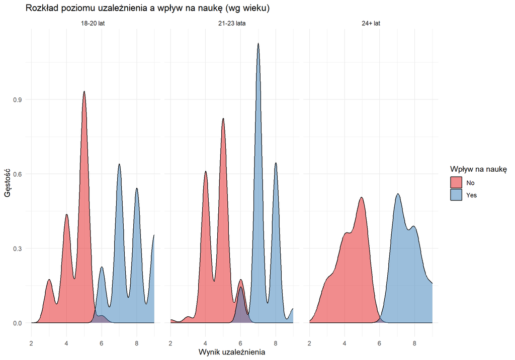

```r
dane_clean <- dane_clean %>%
  mutate(Grupa_wiekowa = case_when(
    Wiek <= 20 ~ "18-20 lat",
    Wiek <= 23 ~ "21-23 lata",
    TRUE ~ "24+ lat"
  ))

ggplot(dane_clean, aes(x = Wynik_uzaleznienia, fill = f.Wplyw_na_wyniki)) +
  geom_density(alpha = 0.5) +
  facet_wrap(~ Grupa_wiekowa) +
  labs(
    title = "Rozkład poziomu uzależnienia a wpływ na naukę (wg wieku)",
    x = "Wynik uzależnienia",
    y = "Gęstość",
    fill = "Wpływ na naukę"
  ) +
  scale_fill_brewer(palette = "Set1") +
  theme_minimal()
```

```r
tabela_wiek_wplyw <- dane_clean %>%
  group_by(Grupa_wiekowa, f.Wplyw_na_wyniki) %>%
  summarise(N = n(), .groups = "drop") %>%
  group_by(Grupa_wiekowa) %>%
  mutate(Procent = round(N / sum(N) * 100, 1)) %>%
  filter(f.Wplyw_na_wyniki == "Yes") %>%
  select(Grupa_wiekowa, N, Procent)

tabela_wiek_wplyw <- dane_clean %>%
  group_by(Grupa_wiekowa, f.Wplyw_na_wyniki) %>%
  summarise(N = n(), .groups = "drop") %>%
  group_by(Grupa_wiekowa) %>%
  mutate(Procent = round(N / sum(N) * 100, 1)) %>%
  filter(f.Wplyw_na_wyniki == "Yes") %>%
  select(Grupa_wiekowa, N, Procent)

tabela_wiek_wplyw %>%
  kbl(caption = "Odsetek osób deklarujących negatywny wpływ mediów na naukę według wieku",
      col.names = c("Grupa wiekowa", "Liczba osób (Yes)", "Procent grupy (%)")) %>%
  kable_styling(full_width = F, bootstrap_options = c("striped", "hover", "condensed")) %>%
  row_spec(0, bold = TRUE, font_size = 12)
```

Odsetek osób deklarujących negatywny wpływ mediów na naukę według wieku

| Grupa wiekowa | Liczba osób (Yes) | Procent grupy (%) |
| --- | --- | --- |
| 18-20 lat | 234 | 68.4 |
| 21-23 lata | 205 | 60.8 |
| 24+ lat | 14 | 53.8 |

```r
dane_clean %>%
  filter(f.Wplyw_na_wyniki == "Yes") %>%
  group_by(Grupa_wiekowa) %>%
  summarise(
    Srednie_uzaleznienie = mean(Wynik_uzaleznienia),
    Mediana = median(Wynik_uzaleznienia),
    N = n()
  ) %>%
  kbl(caption = "Poziom uzależnienia wśród osób deklarujących wpływ na naukę - według wieku",
      col.names = c("Grupa wiekowa", "Średnia", "Mediana", "N"),
      digits = 2) %>%
  kable_styling(full_width = F, bootstrap_options = c("striped", "hover", "condensed")) %>%
  row_spec(0, bold = TRUE, font_size = 12)
```

Poziom uzależnienia wśród osób deklarujących wpływ na naukę - według wieku

| Grupa wiekowa | Średnia | Mediana | N |
| --- | --- | --- | --- |
| 18-20 lat | 7.58 | 8.0 | 234 |
| 21-23 lata | 7.31 | 7.0 | 205 |
| 24+ lat | 7.64 | 7.5 | 14 |

# 6 6. Podsumowanie i Wnioski

Niniejsza analiza, przeprowadzona na próbie 705 osób, miała na celu zbadanie relacji między aktywnością w mediach społecznościowych a dobrostanem psychicznym, snem oraz funkcjonowaniem akademickim studentów. Proces badawczy obejmował przygotowanie danych, analizę opisową oraz wnioskowanie statystyczne, co pozwoliło na empiryczną weryfikację postawionych hipotez. Już na etapie wstępnej obróbki danych potwierdzono ich wysoką jakość – brak braków danych oraz logiczna spójność odpowiedzi świadczyły o wiarygodności materiału empirycznego. Utworzenie zmiennych pochodnych, takich jak kategorie czasu użytkowania czy deficyt snu, umożliwiło pogłębioną analizę wzorców zachowań i stanowiło solidną podstawę dalszych prac.

Test U Manna–Whitneya nie wykazał istotnych różnic w poziomie uzależnienia między płciami, mimo odmiennych preferencji platformowych. Oznacza to, że samo uzależnienie nie jest zjawiskiem zależnym od płci, choć sposób korzystania z mediów może mieć charakter kulturowo zróżnicowany. Jednocześnie test Chi-kwadrat potwierdził istotną zależność między płcią a wyborem platformy, co spójnie uzupełnia wyniki analizy wstępnej.

Szczególnie istotne były wyniki dotyczące funkcjonowania akademickiego. Studenci deklarujący negatywny wpływ mediów społecznościowych na naukę charakteryzowali się istotnie wyższym poziomem uzależnienia (p < 0,001), przy czym grupą najbardziej narażoną okazali się najmłodsi respondenci (18–20 lat). W tej grupie wiekowej blisko dwie trzecie badanych wskazywało na negatywny wpływ aktywności online na wyniki w nauce, co stanowi wyraźny sygnał ostrzegawczy dla szkolnictwa wyższego.

Podsumowując, badanie dostarcza spójnych dowodów na to, że intensywne korzystanie z mediów społecznościowych współwystępuje z obniżonym dobrostanem psychicznym, deficytem snu oraz gorszym funkcjonowaniem akademickim, szczególnie wśród najmłodszych studentów. Wyniki te wskazują na zasadność wdrażania na uczelniach programów wspierających rozwój świadomych nawyków cyfrowych, takich jak warsztaty z higieny cyfrowej, zarządzania czasem oraz psychoedukacji. W kontekście Politechniki Gdańskiej może to stanowić ważny element działań wspierających studentów w pełnym wykorzystaniu ich potencjału akademickiego bez szkody dla zdrowia i dobrostanu.